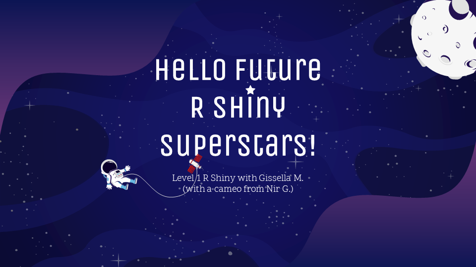

# Overview

Interested in turning your analysis in to sleek, production ready interactive dashboards? This day long workshop will introduce the basics of using R Shiny, the industry standard R Reporting tool, to create your own hosted web applications. By the end of the session you’ll have built your very own fully interactive app in R to simplify a real business problem.

**Requirements:** A good level of knowledge of R is required to participate. If you’re unsure about your experience, contact Gissella or Nir. **To attend you must also ensure, you’ve completed all the Pre-reqs.**

# Structure

We start with understanding what Shiny is and why we’re learning to use it today.

##### After the intro, this workshop is split into 3 key sections:

- Core Shiny 1 - The Shiny structure and building your first app
- Core Shiny 2 - Customisation and going beyond the default Shiny appearance
- Core Shiny 3 - Debugging and deploying your app into the real world

# Projects

The Pre-Requisites section contains 3 datasets to use as a basis for an R Shiny App. You can build an app with most data but we’re restricting today to these three for ease.

##### Current Datasets:

- Predicting Poverty in Costa Rica
- AirBnb & Berlin
- Speed-Dating

# Looking for more information?

Read through the material and interested in learning more?  
Awesome sauce! Checkout the Resources page for further Shiny information and tutorials. If the internet fails you, feel free to email Nir (Nir.Graham@4-most.co.uk) or Gissella (Gissella.Montenegro@4-most.co.uk).